# Mid-term project

Author

Jonathan S. Cárdenas

# 1 Mid-term project GitHub repository URL:

https://github.com/JSCG95/2024dsa_midproject_group11.git

# 2 Introduction

The adaptation of remote sensing and computer vision techniques represents a valuable source of data for plant crop monitoring as it offers a more efficient collection of heterogeneous plant data that complements big data coming from environmental sensors . The true potential of imaging tools lies in the transformation of sensor-derived numerical representation of objects shapes or pixel intensities into meaningful parameters with biological relevance (Fahlgren et al. 2015).

Indoor horticulture benefits from a partial or complete environmental control that provides a consistent productivity. Modern greenhouses rely on the combination of natural and artificial light to avoid losses associated with limited light during winter or cloudy days (Miao et al. 2023) . A contrasting responses of different cultivars to external inputs such as light or temperature has been demonstrated (Lee et al. 2019), highlighting the need of resource optimization strategies at a cultivar level to excel productivity . Moreover, a more efficient use of resources is required to reduce the high energy use associated with controlled conditions, where light takes a significant proportion of the total energy consumption (Jin et al. 2023).

Destructive approaches limit a continuous evaluation of environmental effects on a highly dynamic plant response such as crop yield (Mochida et al. 2019). RGB sensors capturing color information from the red, green and blue bands represent a highly versatile, ubiquitous and accessible tool to grant real-time plant data. An indirect but consistent assessment of plant development response to the environment modulation through an image-based solution generates a more robust criteria for agronomic practices and decision making.

Canopy responses to additional light levels have the potential to enhance leaf area expansion that results in an increase in light interception. Canopy morphology of different cultivars may be more responsive to an increase in light, generating more fresh weight per unit of incident light (Liu and Iersel 2022). Lettuce canopy architecture could be described using two-dimensional (2D) top view RGB captures. Besides canopy projected area, additional shape properties provide a more comprehensive description of plant structure (De Vylder et al. 2012). Tracking changes in canopy morphometric features would help agronomist characterize effects of light on cultivar development across the crop cycle.

In this study, the effect of supplemental light on two Romaine lettuce cultivars leaf fresh weight was evaluated to understand the effect of light on fresh biomass at different time points. Aditionally, an image analysis workflow was implemented to obtain geometrical features from multiple lettuce canopies simultaneously growing hydroponically. These image-derived features were implemented as potential predictors used to fit and compare prediction models with different levels of complexity to obtain the most accurate estimation of lettuce fresh weight.

# 3 Hypothesis and objectives

## 3.1 HYPOTHESIS:

Romaine lettuce cultivars fresh weight respond differently to the supplementation of artificial light under greenhouse conditions.

Lettuce fresh weight per plant is accurately estimated using canopy geometric features extracted using an RGB image analysis and machine learning models.

## 3.2 OBJECTIVES:

- Evaluate the effect of supplemental light on the fresh weight of two romaine lettuce cultivars.
- Extract multiple image features for each plant canopy as potential predictors
- Fit and compare multiple predictive models to estimate accurately lettuce fresh weight.

# 4 Material and Methods

The experiment was carried out in a greenhouse at the University of Georgia (College of Agriculture and Environmental Sciences, Department of Horticulture, Controlled Environment Agriculture Laboratory), Athens, GA, USA (33.93°N, 83.36°W). After transplant, plants were grown for 26 days from 18 October until 13 November 2023.

A deep water culture hydroponics system was used to grow the plants. Six black trays with 243.8 × 121.9 × 20.3 cm (L × W × H) were distributed along a 15,24-m metallic bench inside the greenhouse. Each tray was filled in with 200 liters of fertilizer solution with a polystyrene foam insulation board (GreenGuard XPS; Kingspan Insulation, Atlanta, GA, USA) floating on top of the solution. Additionally, 55 holes with 2.54 cm diameter each were drilled and equally distributed at 18 cm from center to center of each hole giving a plant density of 25 plants/m2 along the foam board forming a 11×5 grid pattern. Inside each hole, individual rockwool plugs with a single seedling were placed into a 4.45 cm top diameter × 3.18 cm bottom diameter × 4.76 cm deep net cup (Orimerc Garden, Seattle, WA). An ePAR quantum sensor (SQ-610 ePAR; Apogee Instruments, Logan, UT, USA) was in the center of each tray’s insulation board measuring PPFD. All sensors were connected to a datalogger (CR1000X; Campbell Scientific, Logan, UT, USA) used to automatically calculate the daily light integral (DLI) attained for each tray with and without supplemental along the crop cycle.

To obtain ground truth measurements per plant, conventional destructive methods of shoot biomass were used to quantify leaf fresh weight (LFW), leaf dry weight (LDW) and leaf area (LA). For LDW, plant shoots were dried in a drying oven for 72 hours at 80 ℃. LA was measured using a leaf area meter (LI-3100; LI-COR, Lincoln, NE, USA) after detaching every leaf. In total, 3 harvests were performed along a 26-day lettuce crop cycle. First, second and third harvest round were performed at 12, 19 and 26 days after transplant, respectively.

## 4.1 Study design

To determine how a specific cultivar responds to supplemental light, the effects of 2 treatment factors were evaluated. The first treatment factor was cultivar where two Romaine lettuce cultivars were selected based on their susceptibility to tip burn, where ‘Dragoon’ was the cultivar with high susceptibility while ‘Chicarita’ the cultivar showing medium susceptibility. The second treatment factor was light where 2 levels either with with (additional LED lights) or without supplemental light (only natural sunlight) were compared.

The experiment was a complete randomized design (CRD), where light treatments were randomly assigned to six plastic trays distributed across a growing bench. Additionally, 26 seedlings for cultivar A and 26 seedlings for cultivar B were randomly distributed within each plastic tray. Each treatment is represented by the combination of light (Y or N) and cultivar (C or D). 3 replicates per treatment were used to calculate means. Leaf fresh weight was measured per plant, and each treatment replicate was calculated as an average of n sampling plants (observational units).

**NOTICE:** Distribution of light fixtures across the trays, imaging sensors and growing trays size limited a proper randomization of light treatment across the growing bench. For this project, we are assuming a proper randomization of light across trays and cultivars within trays.

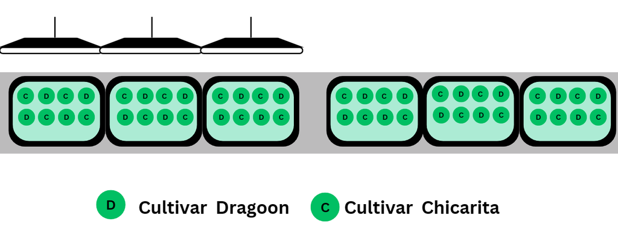

Diagram representing the distribution of the experimental factors across the growing bench.

## 4.2 Statistical analysis

Our response variable (leaf fresh weight) was measured at 3 different time points across the crop cycle: 12, 19 and 26 days after transplant (DAT). Cultivar, light treatment and DAT factors were treated as fixed-effects. A generalized least squared (GLS) model with the appropriate serial correlation structure was used to account for the lack of independence assumption of the non-randomizable harvest time levels in the model. Models were fitted and compared in R software, using packages nlme and lme4. Before using the chosen model for inference, linear assumptions on the model’s residuals were evaluated graphically using the model’s fitted vs residual plot and a Quantile-Quantile plot. A type III analysis of variance (ANOVA) was performed using the specified GLS model, and the mean comparisons were conducted using Tukey’s Honestly Significant Difference (HSD) test at a significance level of 5%.

# 5 Results

```r
# Loading packages
library(tidyverse) # for data wrangling and plotting
library(janitor) # clean column names
library(knitr) # for figure displaying
library(car) # for Anova function
library(lme4)
library(broom) # for model residuals extraction
library(emmeans) # for model mean extraction
library(multcomp) # for pairwise comparison letter display
library(nlme) # for repeated measure correlation structures
library(ggridges)
library(ggcorrplot)
library(nlraa)
library(caret)
library(gridExtra)
```

## 5.1 EDA and Data Wrangling

Loading data tables including remote sensed data, treatment factor columns, response variables (leaf fresh weight, leaf dry weight and leaf area), harvest dates.

```r
raw_data <- read_csv("../files/20-02_feat-matrix.csv")
wr_data <- raw_data %>%
  clean_names() %>%
  dplyr::select(-c("tipburn",'percent_tipburn',
                   "cum_dli","cf")) %>%
  na.omit()
```

Transform treatments into factors and create a new column where each treatment is specified. Set date as date format to calculate DAT.

```r
tr_date  <- mdy('10/18/2023')

wr_data <-wr_data %>%
  mutate(date = mdy(date),
         tray_id = factor(tray_id),
         light = factor(light),
         dat = as.integer(date - tr_date),
         fdat = as.factor(dat),
         fcultivar = factor(cultivar)
         ) %>%
  mutate(trt_id = as.factor(paste0(cultivar, '+',light,'+',tray_id)),
         trt_name = as.factor(paste0(cultivar, '+',light)),
         rep = case_when((trt_id %in% c('C+Y+1','D+Y+1','C+N+4','D+N+4' )) ~ '1',
                             (trt_id %in% c('C+Y+2','D+Y+2','C+N+5','D+N+5' )) ~ '2',
                             (trt_id %in% c('C+Y+3','D+Y+3','C+N+6','D+N+6' )) ~ '3'
         )) %>%
  dplyr::select(-c(melatonin))
```

## 5.2 Box plots: Response Variables distribution.

Treatments distributions plotted based on observational units (raw data).

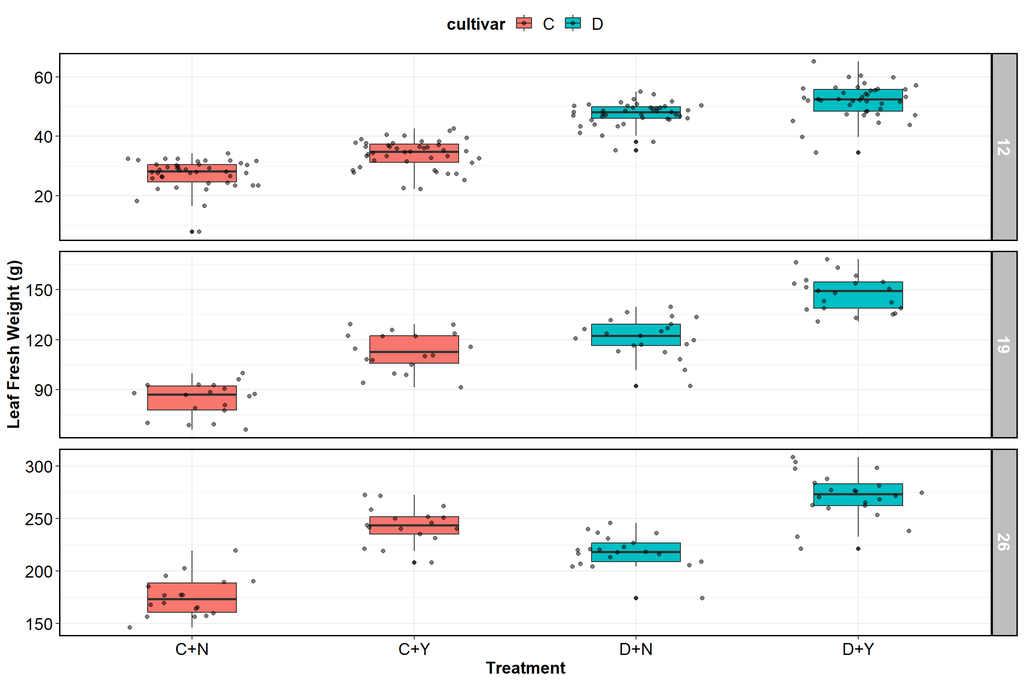

```r
wr_data %>%
  ggplot(aes(x = trt_name,
           y = lfw_g,
           fill = cultivar
           )
       ) +
  geom_boxplot(width = 0.4)+
  geom_jitter(alpha = 0.5,
              width = 0.3) +
  theme_bw()+
  facet_grid(dat~.,
             scales = 'free') +
  theme(plot.title = element_text(size=16,hjust = 0.5, face="bold"),
                   axis.text = element_text(size = 14,color="black"),
                   axis.title = element_text(size = 14, face="bold"),
                   legend.position = "top",
        legend.text = element_text(size = 14),  # Adjust legend text size
        legend.title = element_text(size = 14, face = 'bold'),
        panel.spacing = unit(.6, "lines"),
        panel.border = element_rect(color = "black", fill = NA, size = 1),
        strip.background = element_rect(fill = "gray", color = "black", size = 1),
    strip.text = element_text(size = 14, face = "bold", color = "white"))+
  labs(title=NULL,
       subtitle = NULL,
       caption=NULL,
       x="Treatment",
       y="Leaf Fresh Weight (g)")
```

To fit our statistical model, means for each treatment replicates are necessary. From the raw data, we are extracting averages for each treatment replicates (3 per treatment). Data is grouped by DAT to generate averages for each harvest round.

```r
mean_lfw <- wr_data %>%
  group_by(fcultivar,dat,fdat,light,trt_id, trt_name,rep) %>%
  summarise(n = n(),
            mean = mean(lfw_g),
            sd = sd(lfw_g)) %>%
  mutate(rep = as.factor(rep))
```

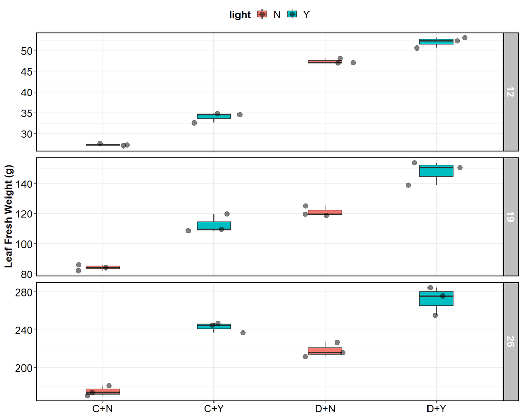

```r
mean_lfw %>%
  ggplot(aes(x = trt_name,
           y = mean,
           fill = light
           )
       ) +
  geom_boxplot(width = 0.3)+
  geom_jitter(alpha = 0.5,
              width = 0.3,
              size = 3) +
  theme_bw()+
  facet_grid(dat~.,
             scales = 'free') +
  theme(plot.title = element_text(size=16,hjust = 0.5, face="bold"),
                   axis.text = element_text(size = 14,color="black"),
                   axis.title = element_text(size = 14, face="bold"),
                   legend.position = "top",
        legend.text = element_text(size = 14),  # Adjust legend text size
        legend.title = element_text(size = 14, face = 'bold'),
        panel.spacing = unit(.6, "lines"),
        panel.border = element_rect(color = "black", fill = NA, size = 1),
        strip.background = element_rect(fill = "gray", color = "black", size = 1),
    strip.text = element_text(size = 14, face = "bold", color = "white"))+
  labs(title=NULL,
       subtitle = NULL,
       caption=NULL,
       x=NULL,
       y="Leaf Fresh Weight (g)")
```

## 5.3 Choosing the right GLS model

The following lines of code fit generalized least square (GLS) model with 3 different correlation structures. This model account for the lack of independence of the time variable, since the response variable leaf fresh weight was measured at 3 different time points. Within the correlation matrix function, the form argument defines the correct time lag (dat in this scenario) specifying the tray-treatment id where the measurements are coming from (i.e., the effects of time that varies across the different replicates of each treatment).

```r
options(contrasts = c("contr.sum", "contr.poly"))

mod_cs <- gls(
  mean ~ light*fcultivar*fdat,
  correlation = corCompSymm(form = ~dat|trt_id),
  data = mean_lfw)


mod_arma <- gls(
  mean ~ light*fcultivar*fdat,
  correlation = corARMA(form = ~dat|trt_id,p = 1, q = 1),
  data = mean_lfw)


mod_car1 <- gls(
  mean ~ light*fcultivar*fdat,
  correlation = corCAR1(form = ~dat|trt_id),
  data = mean_lfw)
```

Is important to highlight here that the harvest were performed at non-equally-spaced time measurements. Notice that nlme package suggest that the autocorrelation function is useful to investigate models for equally spaced data, however in our case the function serves as a useful reference to know if the model specified the right number of lags.

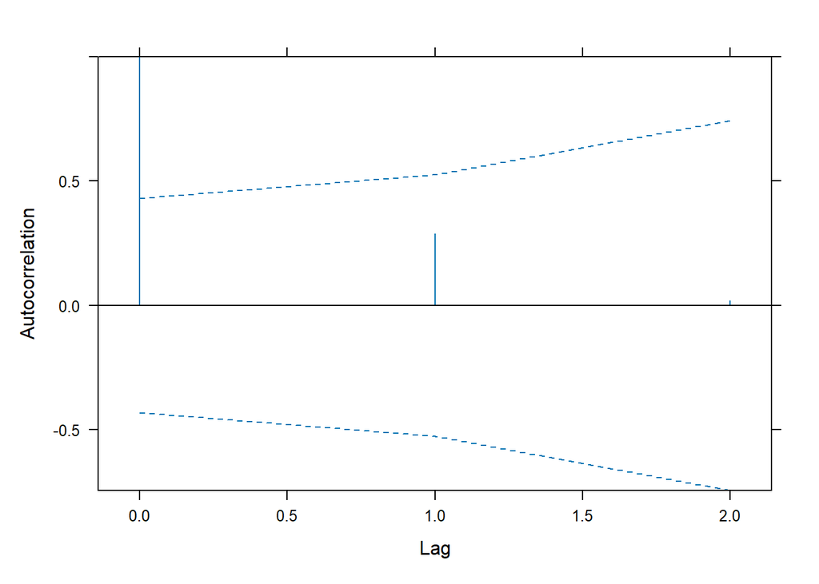

```r
ACF(mod_cs,
    form = ~dat|trt_id,
    resType = "n") %>%
  plot(alpha = 0.01)
```

[figure not shown]

```r
ACF(mod_arma, resType = "n",
    form = ~dat|trt_id) %>%
  plot(alpha = 0.01)
```

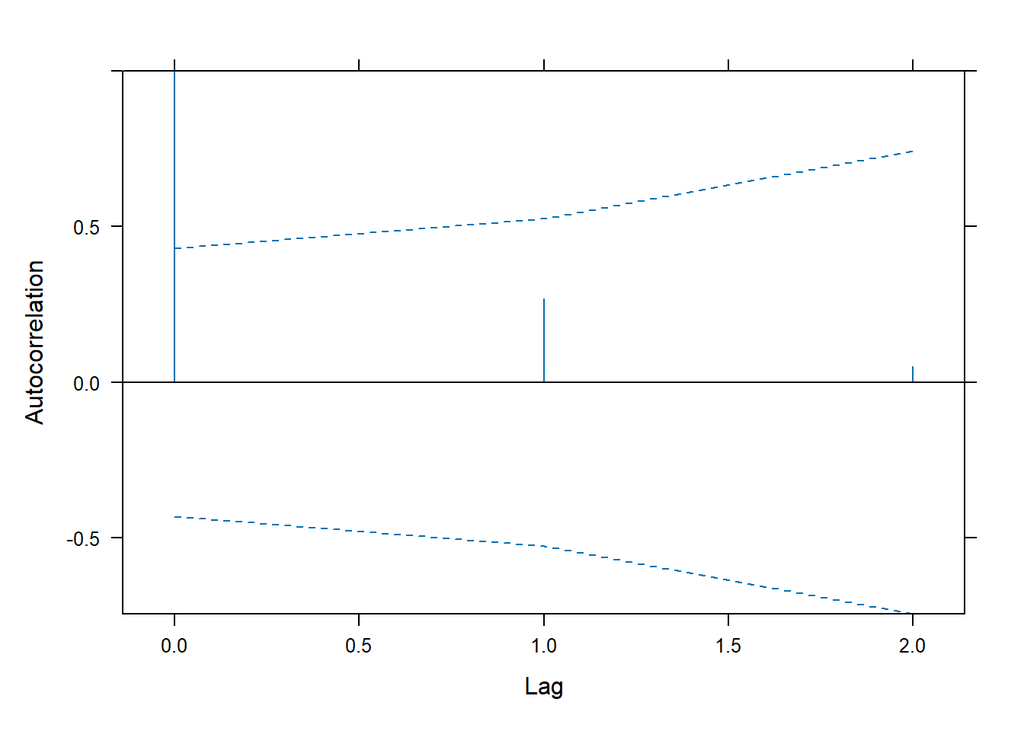

```r
ACF(mod_car1, resType = "n",
    form = ~dat|trt_id) %>%
  plot(alpha = 0.01)
```

```r
anova(mod_cs,
      mod_arma,
      mod_car1)
```

```
         Model df      AIC      BIC    logLik   Test   L.Ratio p-value
mod_cs       1 14 221.3830 237.8757 -96.69149
mod_arma     2 15 224.2519 241.9227 -97.12596 1 vs 2 0.8689361  0.3513
mod_car1     3 14 220.6533 237.1461 -96.32665 2 vs 3 1.5986144  0.2061
```

## 5.4 ANOVA assumptions

BIC and AIC agreed that AR1 was the best model fit for the data. The following plots check if the model assumptions are met. GLS model is not taking into account random effects, therefore only the within groups residuals are considered.

```r
library(broom.mixed)
mod_arma_resid <- augment(mod_arma) %>%
  mutate(.stdresid=resid(mod_arma, type="pearson", scaled=T))

mod_cs_resid <- augment(mod_cs) %>%
  mutate(.stdresid=resid(mod_cs, type="pearson", scaled=T))

mod_car1_resid <- augment(mod_car1) %>%
  mutate(.stdresid=resid(mod_car1, type="pearson", scaled=T))
```

Based on the plot presented above:

- Residuals check the assumption of **independence**, since no particular pattern is evident in the fitted vs residual plot.
- Residuals are slightly increasing across x-axis and showing a fan shape at the right end of the plot. The model might face a problem with the variance homogeneity. Is not so evident so we assume **homoscedasticity** is met.
- Most of the residuals seem to be within the allowance interval. **Outliers** assumption is cleared.

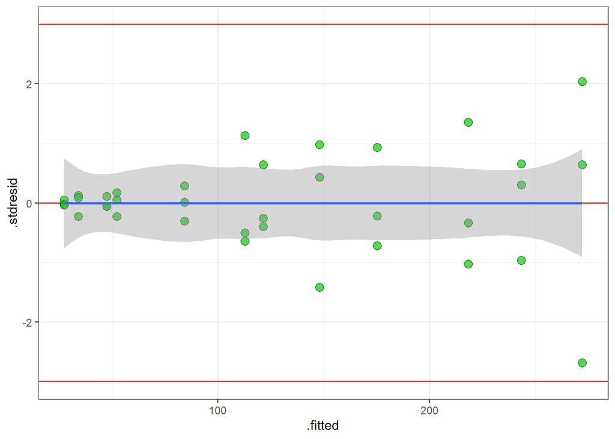

```r
ggplot(mod_car1_resid, aes(x=.fitted, y=.stdresid))+
  geom_hline(yintercept = 0, color="red")+
  geom_point(shape = 21,
             fill = "green3",
             size = 3,
             alpha = .7)+
  geom_smooth()+
  geom_hline(yintercept = c(-3,3), color = "red")+
  theme_bw()
```

The QQ-plot shown below assess the assumption of normality for the AR1(car1) model. Residuals on both tails are skewed, although residuals in the center seem to follow the theoretical normal distribution. The **normality** assumption is met.

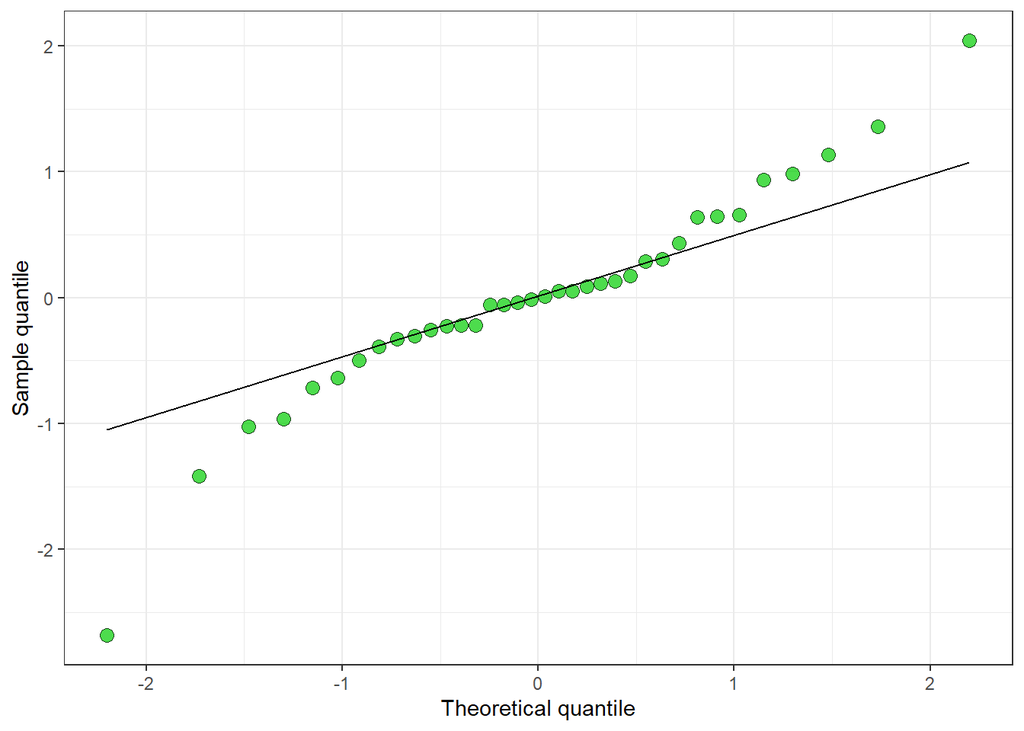

```r
ggplot(mod_car1_resid, aes(sample=.stdresid))+
  stat_qq(  shape = 21,
            fill = "green3",
            size = 3,
            alpha = .7
  )+
  stat_qq_line()+
  labs(x = "Theoretical quantile",
       y = "Sample quantile")+
  theme_bw()
```

Model AR1 met all assumptions for the ANOVA, for this reason it will used for inference to extract the model means. The ANOVA shows a significant interaction between light and DAT, cultivar and DAT, but the interaction between light and cultivar is not significant. Checking at each treatment factor independently there is a significant effect of light and cultivar.

```r
Anova(mod_car1, type = 3)
```

```
Analysis of Deviance Table (Type III tests)

Response: mean
                     Df      Chisq Pr(>Chisq)
(Intercept)           1 10085.1791  < 2.2e-16 ***
light                 1   151.8366  < 2.2e-16 ***
fcultivar             1   142.2843  < 2.2e-16 ***
fdat                  2  6172.0804  < 2.2e-16 ***
light:fcultivar       1     1.4341     0.2311
light:fdat            2   135.2324  < 2.2e-16 ***
fcultivar:fdat        2    18.8602  8.027e-05 ***
light:fcultivar:fdat  2     2.4116     0.2995
---
Signif. codes:  0 '***' 0.001 '**' 0.01 '*' 0.05 '.' 0.1 ' ' 1
```

## 5.5 Extracting means and pairwise comparison

The hypothesis we are testing is if one of the 2 romaine lettuce cultivar responds more effectively to the effect of supplemental light under greenhouse conditions. Even though the interaction was not significant, a comparison among treatment (cultivar + light) addresses more effectively this hypothesis. The mean extraction show below considers the interaction between effect of light and cultivar for each harvest date.

```r
means_extract <- emmeans(mod_car1,
                         ~light:fcultivar|fdat) %>%
  cld(reversed = T,
      Letters = letters,
      adjust = "none"
      ) %>%
  as.data.frame()%>%
  mutate(letter = trimws(.group)) %>%
  mutate(trtname = paste0(fcultivar,"+",light))

means_extract
```

```
   light fcultivar fdat    emmean       SE       df  lower.CL  upper.CL .group
1      Y         D   12  52.06099 3.593191 5.554354  43.09490  61.02707     a
2      N         D   12  47.45429 3.593191 5.554354  38.48820  56.42037     a
3      Y         C   12  34.00662 3.593191 5.554354  25.04053  42.97270      b
4      N         C   12  27.34738 3.593191 5.554354  18.38130  36.31347      b
5      Y         D   19 147.97238 3.593191 5.554354 139.00630 156.93847    a
6      N         D   19 121.29810 3.593191 5.554354 112.33201 130.26418     b
7      Y         C   19 112.77222 3.593191 5.554354 103.80614 121.73831     b
8      N         C   19  84.06222 3.593191 5.554354  75.09614  93.02831      c
9      Y         D   26 272.04923 3.593191 5.554354 263.08314 281.01531   a
11     Y         C   26 243.25167 3.593191 5.554354 234.28558 252.21775    b
10     N         D   26 218.26619 3.593191 5.554354 209.30011 227.23227     c
12     N         C   26 175.24333 3.593191 5.554354 166.27725 184.20942      d
   letter trtname
1       a     D+Y
2       a     D+N
3       b     C+Y
4       b     C+N
5       a     D+Y
6       b     D+N
7       b     C+Y
8       c     C+N
9       a     D+Y
11      b     C+Y
10      c     D+N
12      d     C+N
```

## 5.6 Pairwise comparison plot

We are interested in looking at the comparison of each cultivar fresh weight accumulation across time grown with or without supplemental light. For this, the means were extracted specifying the interaction between the effect of light and cultivar to highlight the different between treatments. The plot displayed below shows the letter separation for the different treatments in a specific harvest day.

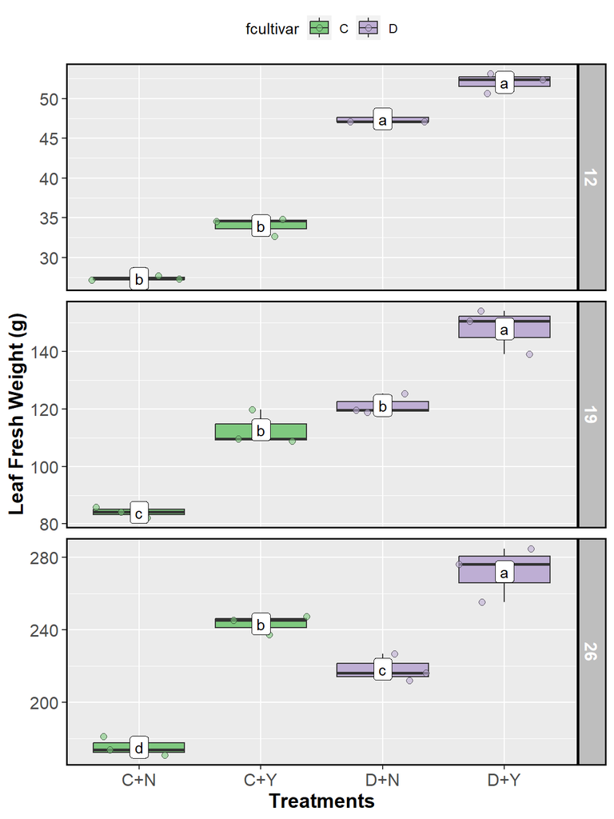

```r
ggplot(mapping = aes(fill = fcultivar))+
  # Raw data and boxplots
  geom_boxplot(data = mean_lfw,
               aes(x = trt_name,
           y = mean,
           fill = fcultivar)) +
  geom_jitter(data = mean_lfw,
               aes(x = trt_name,
                   y = mean),
              shape = 21,
              size = 2,
              alpha = .6) +
  # Adding letters
  geom_label(data = means_extract,
            aes(x = trtname,
                y = emmean,
                label = letter),
            fill = "white") +
  labs(x = "Treatments",
       y = "Leaf Fresh Weight (g)") +
  scale_fill_brewer(palette = "Accent") +
  facet_grid(fdat~.,
             scales = 'free_y') +
  theme(plot.subtitle = element_text(size=14, face="bold"),
                   axis.text.x = element_text(size=12),
                   axis.text.y = element_text(size=12),
                   axis.title.x = element_text(size=14,face="bold"),
                   axis.title.y = element_text(size=14,face="bold"),
                   axis.title = element_text(size = 14, face="bold"),
                   legend.position = "top",
        panel.spacing = unit(.5, "lines"),
        panel.border = element_rect(color = "black", fill = NA, size = 1),
        strip.background = element_rect(fill = "gray", color = "black", size = 1),
    strip.text = element_text(size = 12, face = "bold", color = "white"))
```

The plot above summarized the effect of cultivar and light on lettuce fresh weight across time. On the first harvest date both cultivars regardless of the light conditions where split in two different groups, suggesting that at this time point the observed differences among treatments are explained mainly by cultivar factor. In a second harvest date, the effect of light in the least responsive cultivar ‘Chicarita’ is more evident as it was grouped together with cultivar ‘Dragoon’ grown without light. On last harvest date, all treatments are assigned to different groups with ‘Dragoon’ cultivar growing under supplemental showing the highest fresh weight followed by ‘Chicharita’ cultivar growing under supplemental light too, suggesting that the effect of light is fundamental to explain the difference in fresh weight at this point in time.

## 5.7 Leaf fresh weight Estimation

To facilitate the analysis down this workflow, the original data set was divided into multiple data frames that contains all imaging features that will be used as potential predictors. Additionally, a data frame was created with all the response variables and predictors combined to implement an iterative step.

Feature engineering was used in a different script (20-02_features-eng.R) to combine data coming from different sensors in a single variable that has more biological significance for canopy development. Incident light considers the light intercepted by a defined area of plant canopy, variables coming from the light and RGB sensor, respectively.

```r
predictors <- wr_data %>% dplyr::select(11:20)

response <- wr_data %>% dplyr::select(c('lfw_g'))

matrix <- predictors %>%
  mutate(lfw_g = response$lfw_g)

matrix_resp <- predictors %>%
  mutate(lfw_g = wr_data$lfw_g,
         ldw_g = wr_data$ldw_g,
         la_mm2 = wr_data$la_mm2)
```

## 5.8 Model 1: Baseline model

To determine what is the best image parameter that best explains the variability of the response, the coefficient of determination - R<sup>2</sup> was extracted from all possible linear regressions between 3 responses & 10 potential predictors. The image parameter showing the greatest value was used as the predictor for the baseline simple linear regression.

```r
r2_mods <- matrix_resp %>%
  # Pivotting longer for the response variables
  pivot_longer(cols = lfw_g:la_mm2,
               names_to = "resp_var",
               values_to = "resp_val"
               ) %>%
  # Pivotting longer for the explanatory variables
  pivot_longer(cols = perimeter:inc_light,
               names_to = "exp_var",
               values_to = "exp_val"
               ) %>%
  # Creating groups of resp_var and exp_var
  group_by(resp_var,exp_var) %>%
  nest() %>%
  # Applying linear model to each element
  mutate(lm = map(data,
                  ~lm(resp_val ~ exp_val,
                      data = .x
                      )
                  )) %>%
  # Extracting R2 for each element
  mutate(r2 = map(lm,
                  ~ summary(.x)$r.squared
                  )
         )

r2_mods
```

```
# A tibble: 30 × 5
# Groups:   resp_var, exp_var [30]
   resp_var exp_var      data               lm     r2
   <chr>    <chr>        <list>             <list> <list>
 1 lfw_g    perimeter    <tibble [324 × 2]> <lm>   <dbl [1]>
 2 lfw_g    axis_major   <tibble [324 × 2]> <lm>   <dbl [1]>
 3 lfw_g    axis_minor   <tibble [324 × 2]> <lm>   <dbl [1]>
 4 lfw_g    eccentricity <tibble [324 × 2]> <lm>   <dbl [1]>
 5 lfw_g    convex_hull  <tibble [324 × 2]> <lm>   <dbl [1]>
 6 lfw_g    compactness  <tibble [324 × 2]> <lm>   <dbl [1]>
 7 lfw_g    extent       <tibble [324 × 2]> <lm>   <dbl [1]>
 8 lfw_g    diameter     <tibble [324 × 2]> <lm>   <dbl [1]>
 9 lfw_g    area_cm2     <tibble [324 × 2]> <lm>   <dbl [1]>
10 lfw_g    inc_light    <tibble [324 × 2]> <lm>   <dbl [1]>
# ℹ 20 more rows
```

Only the features with the top 3 greatest R<sup>2</sup> values are shown.

```r
top_r2 <- r2_mods %>%
  unnest(r2) %>%
  group_by(resp_var)  %>%
  arrange(desc(r2),resp_var) %>%
  slice(1:3) %>%
  mutate(r2 = round(r2,3))
```

A data frame with the top 3 features per variable created above was used to generate scatterplots showing the potential predictor on the x-axis and the biomass response on the y-axis (fresh weight, dry weight or leaf area).

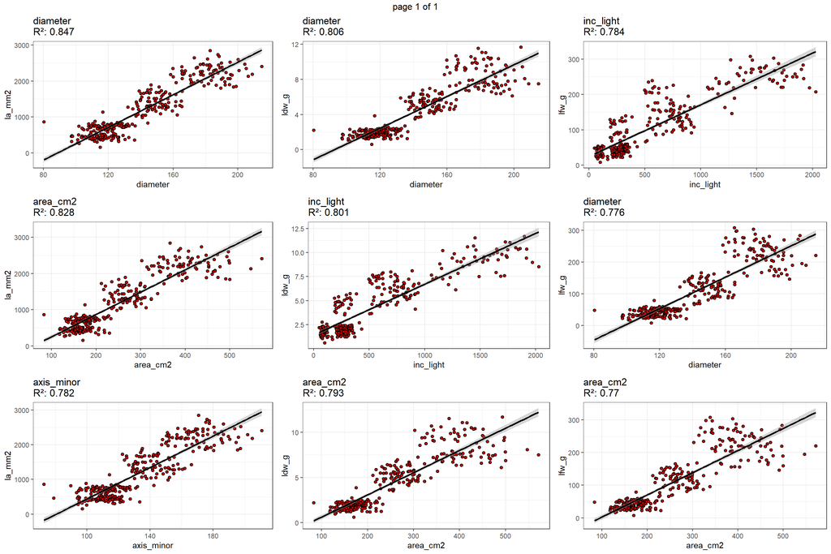

```r
lm_plots <- top_r2 %>%
  mutate(splot = map2(data,r2,
                      ~ ggplot(data = .x,
                               aes(x = exp_val,
                                   y = resp_val)
                               ) +
                        geom_point()+
                        geom_smooth(method = 'lm') +
                        labs(title = paste("R\u00B2",.y))

                      )
         ) %>%
  mutate(splot_better = pmap(
    list(.df = data,
         .r2 = r2,
         .rv = resp_var,
         .ev = exp_var
         ),
    function(.df,.r2,.rv,.ev)
      ggplot(data = .df,
                               aes(x = exp_val,
                                   y = resp_val)
                               ) +
                        geom_point(color = "black",
                                   shape = 21,
                                   size = 1.5,
                                   stroke = 0.7,
                                   fill = 'red3') +
                        geom_smooth(method = 'lm',
                                    color = "black") +
                        theme_bw() +
                        labs(title = paste(.ev,"\nR\u00B2:", .r2),

                             x = .ev,
                             y = .rv
                             )))



linear_plots <- marrangeGrob(lm_plots$splot_better,
                         nrow = 3,
                         ncol = 3)

linear_plots
```

The following table summarizes the coefficient of determination (R<sup>2</sup>) values chosen for each response variable. In the following steps, only leaf fresh weight will be considered as the response variable.

Top 3 predictors with the largest coefficient of determination values for the 3 responses variables

[output not shown]

### 5.8.1 Assumptions for the best predictor

Incident light showed the greatest R<sup>2</sup> to predict fresh biomass. This variable combines canopy area information with the amount of light received until a specific time point measured using a light sensor (cumulative DLI).

The summary of a simple linear regression using incident light as the only predictor variable for fresh estimation is presented below. Additionally, a fitted vs residuals plot is displayed to show if the predictor is in fact linearly correlated with the response or if there is a consistent variability of the residuals across the range of predicted values. We expect fitting a model that has a similar error across the range of predicted values.

```r
options(contrasts = c("contr.sum", "contr.poly"))

# Model fitting: Because SR is numerical, will give us a slope.
lfw_lin<- lm(lfw_g ~ inc_light,
                 data = matrix_resp)

summary(lfw_lin)
```

```
Call:
lm(formula = lfw_g ~ inc_light, data = matrix_resp)

Residuals:
     Min       1Q   Median       3Q      Max
-113.441  -25.908   -8.675   17.964  133.400

Coefficients:
             Estimate Std. Error t value Pr(>|t|)
(Intercept) 24.427107   3.131900   7.799 8.73e-14 ***
inc_light    0.146542   0.004283  34.213  < 2e-16 ***
---
Signif. codes:  0 '***' 0.001 '**' 0.01 '*' 0.05 '.' 0.1 ' ' 1

Residual standard error: 37.6 on 322 degrees of freedom
Multiple R-squared:  0.7843,    Adjusted R-squared:  0.7836
F-statistic:  1171 on 1 and 322 DF,  p-value: < 2.2e-16
```

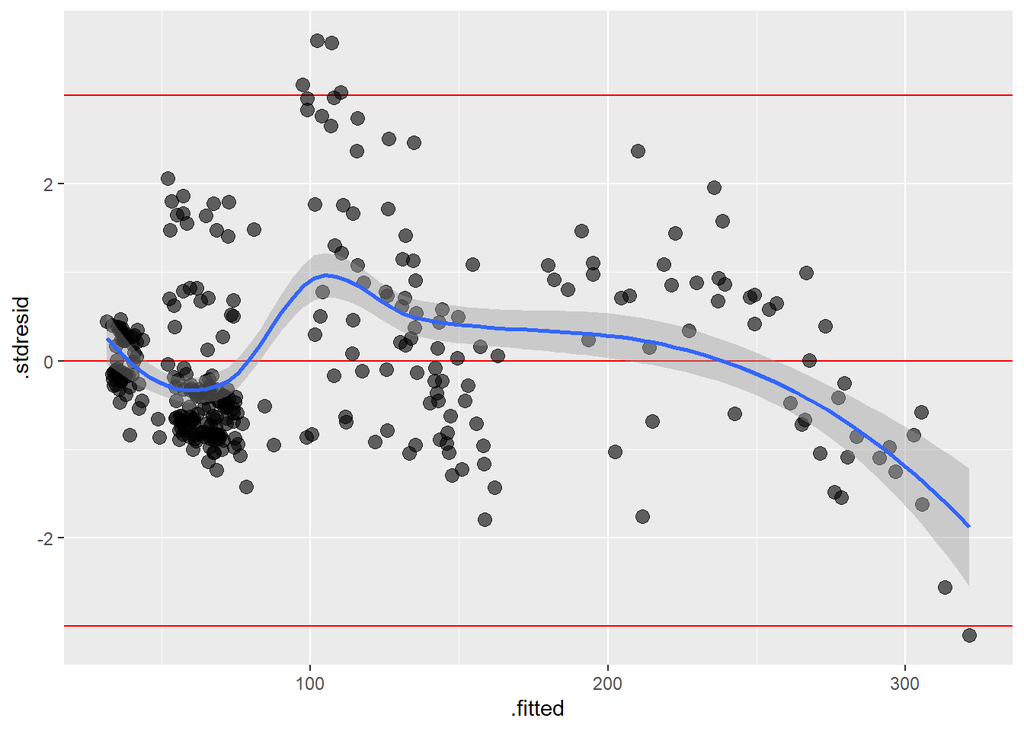

```r
lfw_lin_aug <- augment(lfw_lin) %>%
  mutate(.stdresid = rstudent(lfw_lin))

ggplot(lfw_lin_aug,
       aes(x = .fitted,
           y = .stdresid))+
  geom_hline(yintercept = 0, color = "red")+
  geom_hline(yintercept = c(-3,3), color = "red")+
  geom_point(size = 3, alpha = .6)+
  geom_smooth()
```

Based on the plot shown above, there seem to be a noticeable pattern across the range of fitted values. The linear relationship between the only predictor and the response seems to be ignoring a non-linear pattern at the end of the x-axis as we as a noticeable change right in the middle. Therefore, is necessary to look for the addition of terms that better captures that particular pattern in the residuals.

### 5.8.2 Improving model fit

Destructive measurements and remote sensed data were captured at 3 time points along the crop cycle. As the objective is to fit a single model that predicts fresh biomass on any given day, the right linear or non-linear fit between the best predictor must be found. The first option was to fit a quadratic model, adding a quadratic term of the predictor incident light.

```r
options(contrasts = c("contr.sum", "contr.poly"))

# Model fitting: Because SR is numerical, will give us a slope.
lfw_quad<- lm(lfw_g ~ inc_light + I(inc_light^2) ,
                 data = matrix_resp)
summary(lfw_quad)
```

```
Call:
lm(formula = lfw_g ~ inc_light + I(inc_light^2), data = matrix_resp)

Residuals:
   Min     1Q Median     3Q    Max
-82.51 -25.39  -7.88  21.00 122.94

Coefficients:
                 Estimate Std. Error t value Pr(>|t|)
(Intercept)     5.868e+00  4.508e+00   1.302    0.194
inc_light       2.254e-01  1.487e-02  15.152  < 2e-16 ***
I(inc_light^2) -4.560e-05  8.272e-06  -5.513 7.26e-08 ***
---
Signif. codes:  0 '***' 0.001 '**' 0.01 '*' 0.05 '.' 0.1 ' ' 1

Residual standard error: 35.99 on 321 degrees of freedom
Multiple R-squared:  0.8029,    Adjusted R-squared:  0.8017
F-statistic: 653.9 on 2 and 321 DF,  p-value: < 2.2e-16
```

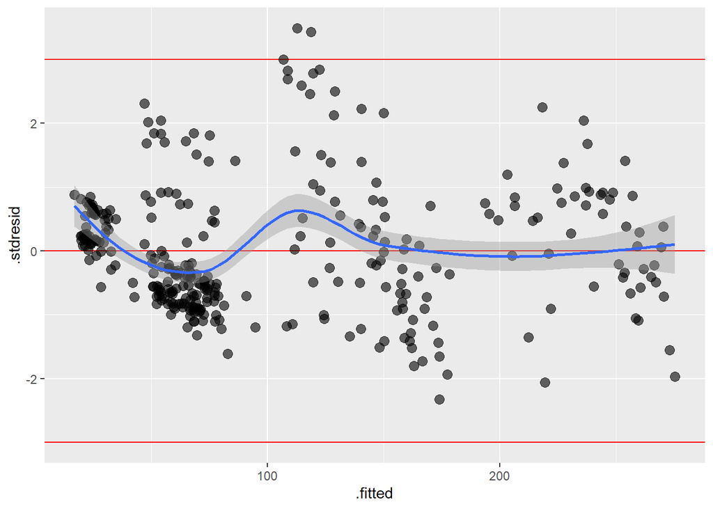

```r
lfw_quad_aug <- augment(lfw_quad) %>%
  mutate(.stdresid = rstudent(lfw_quad))

ggplot(lfw_quad_aug,
       aes(x = .fitted,
           y = .stdresid))+
  geom_hline(yintercept = 0, color = "red")+
  geom_hline(yintercept = c(-3,3), color = "red")+
  geom_point(size = 3, alpha = .6)+
  geom_smooth()
```

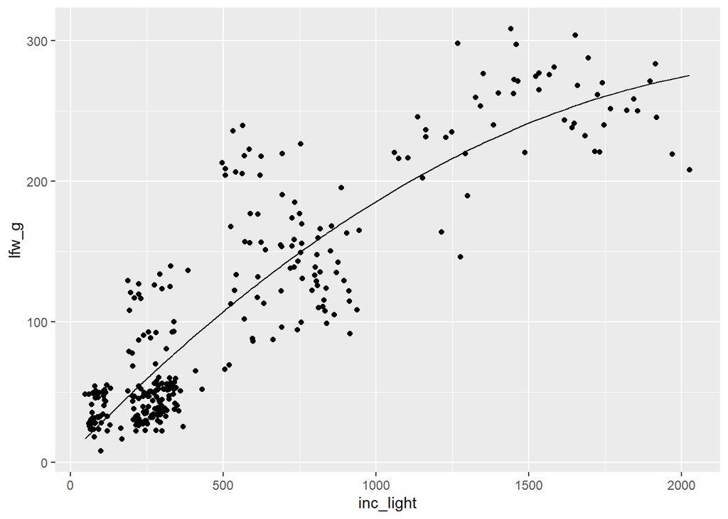

```r
ggplot(data = matrix_resp, aes(x = inc_light, y = lfw_g)) +
geom_point() +
geom_line(aes(y = fitted(lfw_quad)))
```

As shown by the R<sup>2</sup> value in the quadratic model summary, adding a quadratic term improved the variability captured by the model. Moreover, the fitted vs residual plot calculate based on quadratic model, shows a better capacity to capture the trends on the residuals especially on the largest fitted values.

Additionally, a non- linear logistic regression is implemented using the R package nls. To automatically set the values for the equation terms, the function SSlogic() was implemented.

```r
lfw_log = nls(lfw_g ~ SSlogis(inc_light, a, b,c),
            data = matrix_resp)

summary(lfw_log)
```

```
Formula: lfw_g ~ SSlogis(inc_light, a, b, c)

Parameters:
  Estimate Std. Error t value Pr(>|t|)
a  265.030      8.248   32.13   <2e-16 ***
b  670.227     31.617   21.20   <2e-16 ***
c  321.267     20.574   15.62   <2e-16 ***
---
Signif. codes:  0 '***' 0.001 '**' 0.01 '*' 0.05 '.' 0.1 ' ' 1

Residual standard error: 35.75 on 321 degrees of freedom

Number of iterations to convergence: 2
Achieved convergence tolerance: 8.527e-06
```

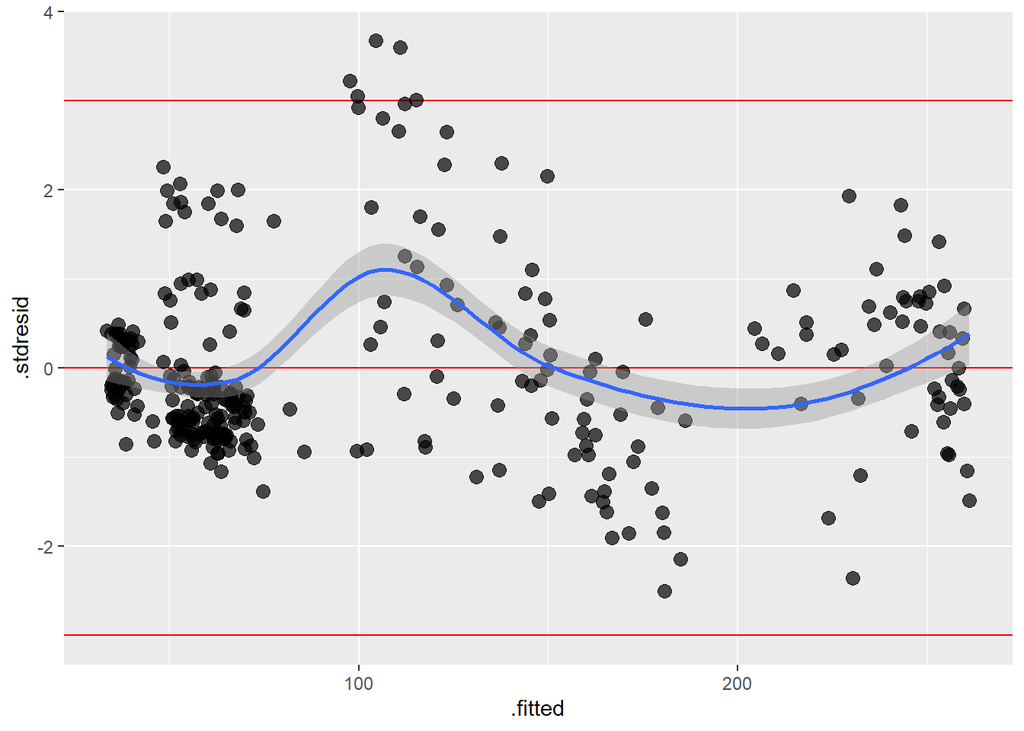

```r
lfw_log_aug <- augment(lfw_log) %>%
  mutate(.stdresid = resid(lfw_log,
                           type = "pearson",
                           scaled = T))

ggplot(lfw_log_aug,
       aes(x = .fitted,
           y = .stdresid))+
  geom_hline(yintercept = 0, color = "red")+
  geom_hline(yintercept = c(-3,3), color = "red")+
  geom_point(size = 3, alpha = .7)+
  geom_smooth()
```

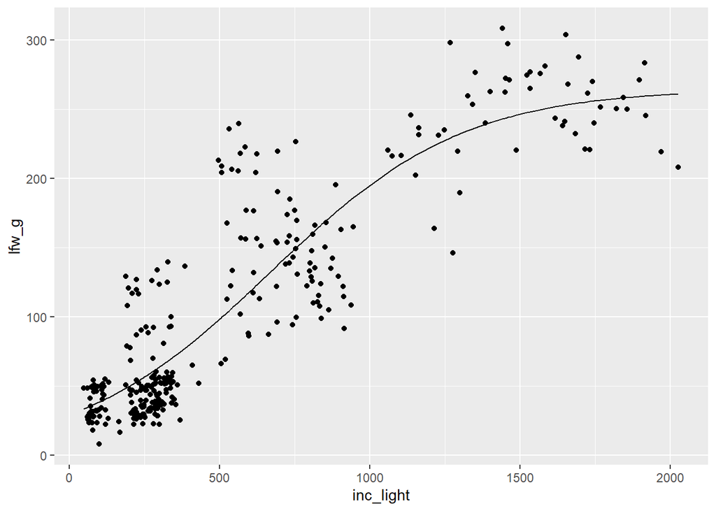

```r
ggplot(data = matrix_resp, aes(x = inc_light, y = lfw_g)) +
geom_point() +
geom_line(aes(y = fitted(lfw_log)))
```

The logistic regression did not captured precisely the pattern of the fitted values around 200, however this model shows a lower residual standard error than the quadratic model. For this reason, the logistic model that uses incident light as the only predictor variable is set as the baseline.

## 5.9 Correlations among predictors

To assess a potential risk of multicollinearity among predictors, a correlation matrix based on Pearson’s Correlation Coefficient (r) is plotted to check how linearly correlated the potential predictors are.

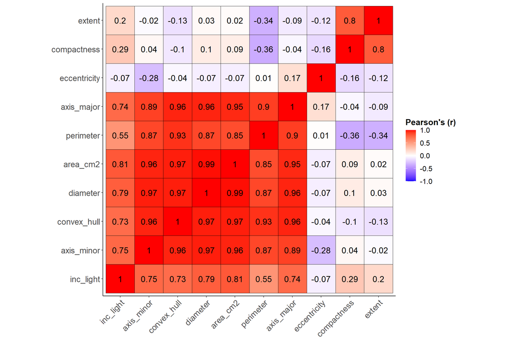

```r
corr_percent <- round(cor(predictors),2)
p.mat <- cor_pmat(predictors)

ggcorrplot(corr_percent, hc.order = TRUE,
           ggtheme = theme_classic(),
           legend.title = "Pearson's (r) " ,
           outline.color = "black",
           type = "full",
           lab = TRUE,
           lab_size = 5,
           tl.cex = 14,
           tl.col = "black") +
    theme(legend.title = element_text(size=14, face = "bold"),
          legend.text = element_text(size=12))
```

The level of multicollinearity among 7 out of 10 predictors is high. To address this problem, a multiple linear regression fitted based on the variables that show the lowest variance inflation factor (VIF) when using simultaneously in a model will be used. Additionally, LASSO regression will be implemented as an alternative option, as this model penalizes predictors that do not contribute significantly.

## 5.10 Model 2: Multiple Linear Regression

In this section, a multiple linear regression model with a reduced set of predictors was fitted. The variable selection was based on two criteria: VIF and biological/geometrical criteria to choose the variables that are more representative to describe canopy shape.

```r
full_mlr<- lm(lfw_g ~ ., data  = matrix)
summary(full_mlr)
```

```
Call:
lm(formula = lfw_g ~ ., data = matrix)

Residuals:
    Min      1Q  Median      3Q     Max
-91.990 -15.925  -2.019  15.739  86.316

Coefficients:
               Estimate Std. Error t value Pr(>|t|)
(Intercept)  -1.360e+02  7.148e+01  -1.903   0.0580 .
perimeter    -2.556e-01  5.757e-02  -4.441 1.25e-05 ***
axis_major    8.907e-01  6.944e-01   1.283   0.2005
axis_minor    6.225e-01  8.721e-01   0.714   0.4759
eccentricity -1.776e+01  4.301e+01  -0.413   0.6800
convex_hull  -2.904e-03  1.728e-03  -1.681   0.0938 .
compactness  -1.646e+02  8.216e+01  -2.003   0.0461 *
extent        4.821e+01  4.150e+01   1.162   0.2462
diameter      2.464e+00  1.298e+00   1.898   0.0586 .
area_cm2     -1.714e-01  1.091e-01  -1.571   0.1172
inc_light     7.102e-02  6.049e-03  11.742  < 2e-16 ***
---
Signif. codes:  0 '***' 0.001 '**' 0.01 '*' 0.05 '.' 0.1 ' ' 1

Residual standard error: 26.88 on 313 degrees of freedom
Multiple R-squared:  0.8928,    Adjusted R-squared:  0.8894
F-statistic: 260.8 on 10 and 313 DF,  p-value: < 2.2e-16
```

```r
full_mlr %>%
  vif()
```

```
   perimeter   axis_major   axis_minor eccentricity  convex_hull  compactness
   28.418520   227.034710   262.134355    12.757339    85.447816    10.484552
      extent     diameter     area_cm2    inc_light
    2.919177   623.008848    58.191937     3.902768
```

```r
vif_mlr<- lm(lfw_g ~ inc_light + convex_hull + compactness  , data  = matrix)

summary(vif_mlr)
```

```
Call:
lm(formula = lfw_g ~ inc_light + convex_hull + compactness, data = matrix)

Residuals:
    Min      1Q  Median      3Q     Max
-96.372 -17.501  -4.059  15.969  90.940

Coefficients:
              Estimate Std. Error t value Pr(>|t|)
(Intercept) -2.607e+02  2.978e+01  -8.753  < 2e-16 ***
inc_light    7.909e-02  5.700e-03  13.875  < 2e-16 ***
convex_hull  4.879e-03  3.350e-04  14.566  < 2e-16 ***
compactness  2.661e+02  3.250e+01   8.187 6.45e-15 ***
---
Signif. codes:  0 '***' 0.001 '**' 0.01 '*' 0.05 '.' 0.1 ' ' 1

Residual standard error: 29.18 on 320 degrees of freedom
Multiple R-squared:  0.8709,    Adjusted R-squared:  0.8697
F-statistic: 719.4 on 3 and 320 DF,  p-value: < 2.2e-16
```

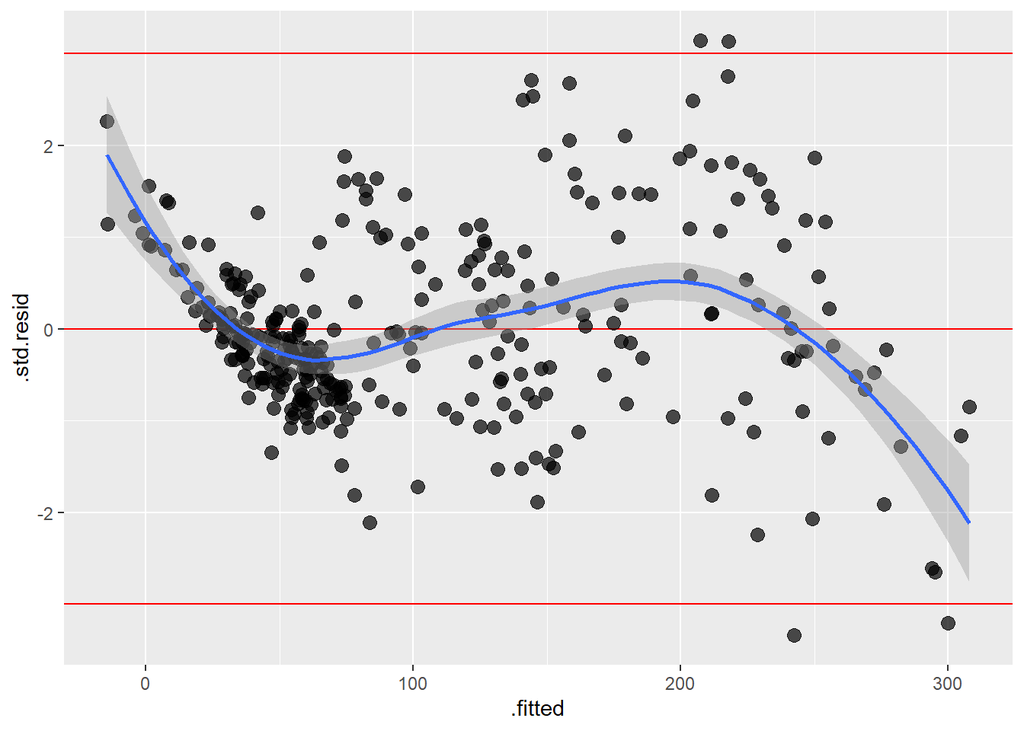

```r
lfw_vif_aug <- augment(vif_mlr) %>%
  mutate(.stdresid = resid(vif_mlr,
                           type = "pearson",
                           scaled = T))

ggplot(lfw_vif_aug,
       aes(x = .fitted,
           y = .std.resid))+
  geom_hline(yintercept = 0, color = "red")+
  geom_hline(yintercept = c(-3,3), color = "red")+
  geom_point(size = 3, alpha = .7)+
  geom_smooth()
```

```r
vif_mlr %>%
  vif()
```

```
  inc_light convex_hull compactness
   2.940979    2.725668    1.392294
```

By keeping the least correlated predictors and selecting the variables that portrait heterogeneous information of that canopy shape, we obtained a MLR model with variables with highly significant coefficients.Additionally, the VIFs for the 3 variables selected are below 5.

## 5.11 Machine Learning Models

### 5.11.1 Data partition: Test-train split available

Here, I’m dropping the variables area_cm2 and diameter as I know ahead that incident light is capturing the same information being captured by these 2. As we will start using a machine learning approach to find the model that yields the most accurate prediction, our full dataset will be split in a training and a testing data set. Plant observation on the training set will be used to find the values of the hypertuning parameters for the models that require a hyperparameter specification (in our case: LASSO and random forest).

```r
matrix_alt <- matrix %>%
  dplyr::select(-c(diameter, area_cm2))

# Partition data and create index matrix of selected values
index <- createDataPartition(matrix_alt$lfw_g,
                             p=.8,
                             list=FALSE,
                             times=1)

set.seed(20)
# Create test and train data frames
train_df <- matrix_alt[index,]
test_df <- matrix_alt[-index,]
```

### 5.11.2 Model 3: LASSO Regression

```r
# Specify 10-fold cross-validation as training method
cv_5 <- trainControl(method="cv",
                          number=5,
                          savePredictions="all")
```

LASSO implements a penalty (lambda value) that is a threshhold to reject variables with insignificant contribution to the model predictions. The following vector creates 500 different possible values for lambda. We want to find the value of lambda that gives the minimum MSE.

```r
lambda_vector <- 10^seq(2, -5, length=500)
```

```r
# Set seed for reproducible random selection and assignment operations
set.seed(123)

# Specify lasso regression model to be estimated using training data
# and k-fold cross-validation process
lfw_lasso <- train(lfw_g ~.,
                data=train_df,
                preProcess=c("center","scale"),
                method="glmnet",
                tuneGrid=expand.grid(alpha=1, lambda=lambda_vector),
                trControl=cv_5,
                na.action=na.omit)
```

```r
lamb_best<- lfw_lasso$bestTune$lambda


perf_lambda <- data.frame(lfw_lasso$results$Rsquared,
                   lfw_lasso$results$lambda,
                   lfw_lasso$results$RMSE) %>%
  rename(R2 = lfw_lasso.results.Rsquared,
         lambda = lfw_lasso.results.lambda,
         RMSE = lfw_lasso.results.RMSE) %>%
  filter(lambda == lamb_best)
```

The table below shows the coefficient for the variables that were selected after fitiing a model using the best lambda penalty selected using cross-validation.

```r
coef(lfw_lasso$finalModel, lfw_lasso$bestTune$lambda)
```

```
9 x 1 sparse Matrix of class "dgCMatrix"
                     s1
(Intercept)  104.994269
perimeter    -25.798591
axis_major    35.025881
axis_minor    32.441917
eccentricity   .
convex_hull    .
compactness    0.681977
extent         4.079205
inc_light     35.972021
```

Additionally, varImp function displays the variables in descending order from the variable that had more importance for leaf fresh weight predictions to the variables that did not influence or that were rejected by the lambda penalty.

```r
varImp(lfw_lasso)
```

```
glmnet variable importance

             Overall
inc_light    100.000
axis_major    97.370
axis_minor    90.187
perimeter     71.718
extent        11.340
compactness    1.896
convex_hull    0.000
eccentricity   0.000
```

### 5.11.3 Model 4: Random Forest

```r
rf_grid <- expand.grid(.mtry = c(2, 5,10))  # Number of variables to sample as candidates at each split

set.seed(123)
# Fit the random forest model
lfw_rf <- train(lfw_g ~ .,
                data = train_df,
                method = "rf",
                trControl = cv_5,
                tuneGrid = rf_grid,
                na.action = na.omit)
```

After training the random forest model to find the best hyperparameter mtry, a summary table is provided that shows what is the change in root mean squared error depending on which mtry is used.

```r
perf_rf <- data.frame(lfw_rf$results$Rsquared,
                   lfw_rf$results$mtry,
                   lfw_rf$results$RMSE) %>%
  rename(R2 = lfw_rf.results.Rsquared,
         mtry = lfw_rf.results.mtry,
         RMSE = lfw_rf.results.RMSE)

perf_rf
```

```
         R2 mtry     RMSE
1 0.9403323    2 21.04076
2 0.9410430    5 20.64596
3 0.9328121   10 22.01579
```

## 5.12 Predictions performance using test set

```r
# Load the necessary library
library(purrr)

# Create a list of models
models <- list(lfw_log,vif_mlr, lfw_lasso,lfw_rf)

# Use map to apply the predict function to each model
predictions <- models %>%
  map(~ predict(., newdata = test_df)) %>%
  set_names(c("Logistic","MLR VIF", "LASSO", "Random Forest")) %>%
  bind_cols()
```

In the following table , a summary of 3 performance metrics for all models is presented based, calculated using unseen observations coming from the testing data set.

```r
calculate_performance <- function(predicted_values, actual_values) {
  data.frame(
    RMSE = caret::RMSE(predicted_values, actual_values),
    Rsquared = caret::R2(predicted_values, actual_values),
    MAPE = ie2misc::mape(predicted_values, actual_values)
  )
}
```

```r
performance_df <- map_dfr(names(predictions), ~{
  calculate_performance(predictions[[.x]], test_df$lfw_g) %>%
    mutate(names = .x) %>%
    arrange(desc(RMSE))
})

performance_df
```

```
      RMSE  Rsquared     MAPE         names
1 40.99636 0.7239354 39.89859      Logistic
2 33.49366 0.8195399 32.95111       MLR VIF
3 31.45735 0.8465615 29.00853         LASSO
4 21.86523 0.9283020 20.44027 Random Forest
```

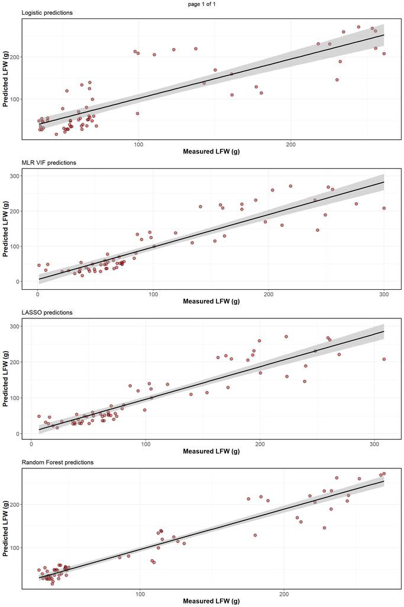

```r
scatter_test = map(names(predictions),
                      ~ ggplot(data = predictions,
                               aes(x = .data[[.x]],
                                   y = test_df$lfw_g)
                               ) +
              geom_point(color = "black",shape = 21,
                         size = 2.3, fill = "red3",
                         stroke = 1,
                         alpha = 0.5)+
              geom_smooth(method = 'lm',
                          color = "black") +
              theme_bw()+
              labs(title = paste(.x, 'predictions'),
                   caption=NULL,x="Measured LFW (g)",
                   y="Predicted LFW (g)") +
                theme(plot.subtitle = element_text(size=14, face="bold"),
                   axis.text.x = element_text(size=12),
                   axis.text.y = element_text(size=12),
                   axis.title.x = element_text(size=14,face="bold"),
                   axis.title.y = element_text(size=14,face="bold"),
                   axis.title = element_text(size = 14, face="bold"),
                   legend.position = "top",
        panel.spacing = unit(.5, "lines"),
        panel.border = element_rect(color = "black", fill = NA, size = 1),
        strip.background = element_rect(fill = "gray", color = "black", size = 1),
    strip.text = element_text(size = 12, face = "bold", color = "white")))

scatter_plots <- marrangeGrob(scatter_test,
                         nrow = 4,
                         ncol = 1)
scatter_plots
```

## 6 References

De Vylder, Jonas, Filip Vandenbussche, Yuming Hu, Wilfried Philips, and Dominique Van Der Straeten. 2012. “Rosette Tracker: An Open Source Image Analysis Tool for Automatic Quantification of Genotype Effects.” *Plant Physiology* 160 (3): 1149–59. https://doi.org/10.1104/pp.112.202762.

Fahlgren, Noah, Maximilian Feldman, Malia A. Gehan, Melinda S. Wilson, Christine Shyu, Douglas W. Bryant, Steven T. Hill, et al. 2015. “A Versatile Phenotyping System and Analytics Platform Reveals Diverse Temporal Responses to Water Availability in Setaria.” *Molecular Plant* 8 (10): 1520–35. https://doi.org/10.1016/j.molp.2015.06.005.

Jin, Wenqing, Yongran Ji, Dorthe H. Larsen, Yang Huang, Ep Heuvelink, and Leo F. M. Marcelis. 2023. “Gradually Increasing Light Intensity During the Growth Period Increases Dry Weight Production Compared to Constant or Gradually Decreasing Light Intensity in Lettuce.” *Scientia Horticulturae* 311 (March): 111807. https://doi.org/10.1016/j.scienta.2022.111807.

Lee, Ru Ji, Shiva Ram Bhandari, Gongin Lee, and Jun Gu Lee. 2019. “Optimization of Temperature and Light, and Cultivar Selection for the Production of High-Quality Head Lettuce in a Closed-Type Plant Factory.” *Horticulture, Environment, and Biotechnology* 60 (2): 207–16. https://doi.org/10.1007/s13580-018-0118-8.

Liu, Jun, and Marc W. van Iersel. 2022. “Far-Red Light Effects on Lettuce Growth and Morphology in Indoor Production Are Cultivar Specific.” *Plants* 11 (20): 2714. https://doi.org/10.3390/plants11202714.

Miao, Chen, Shaojun Yang, Jing Xu, Hong Wang, Yongxue Zhang, Jiawei Cui, Hongmei Zhang, et al. 2023. “Effects of Light Intensity on Growth and Quality of Lettuce and Spinach Cultivars in a Plant Factory.” *Plants* 12 (18): 3337. https://doi.org/10.3390/plants12183337.

Mochida, Keiichi, Satoru Koda, Komaki Inoue, Takashi Hirayama, Shojiro Tanaka, Ryuei Nishii, and Farid Melgani. 2019. “Computer Vision-Based Phenotyping for Improvement of Plant Productivity: A Machine Learning Perspective.” *GigaScience* 8 (1): giy153. https://doi.org/10.1093/gigascience/giy153.